# Praca domowa 2

Cezary Polkowski

## Dane

Dane wykorzystane w Pracy domowej 2 opisują wycenę nieruchmości. Każda obserwacja jest pewną nieruchmością, która posiada informacje takie jak powierzchnia, liczba pokoi, liczba łazienek i wiele więcj. Opis wszystkich kolumn w pliku `README.md`.

## Zadanie 1

Jak wygląda rozkład ceny nieruchomości w poszczególnych kodach pocztowych na przestrzeni lat? Rozważamy kody pocztowe, które mają więcej niż 280 posiadłości.

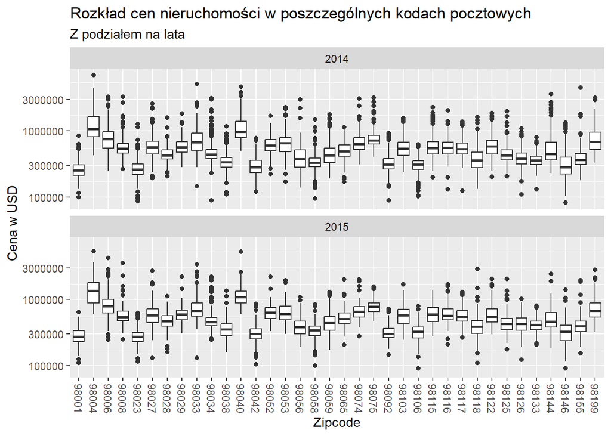

```r
df %>%
  group_by(zipcode) %>%
  summarise(ilosc = n()) %>%
  filter(ilosc > 280) %>%
  left_join(df, join_by(zipcode)) %>%
  mutate(year = substr(date,1,4)) %>%
  select(zipcode, price, year) %>%

  ggplot(aes(x = factor(zipcode), y = price)) + geom_boxplot() +
  facet_wrap(~ year, ncol = 1) +
  scale_x_discrete(guide = guide_axis( title = "Zipcode", angle = -90)) +
  scale_y_log10(labels = function(x) format(x, scientific = FALSE)) +
  labs(x = "Kod Pocztowy", y = "Cena w USD", title = "Rozkład cen nieruchomości w poszczególnych kodach pocztowych", subtitle = "Z podziałem na lata")
```

**Komentarz: Tak wyglądają wykresy rozkładu ceny nieruchomości w poszczególnych kodach pocztowych z podziałem na lata**

## Zadanie 2

Czy jest różnica w rozkładzie ceny nierchomości od powierzchni mieszkalnej uwzględniając podział na nieruchomości z piwnicą i bez?

[figure not shown]

```r
df %>%
  mutate(has_basement = sqft_basement != 0) %>%
  select(price, sqft_living, has_basement) %>%

  ggplot(aes(x = sqft_living, y = price, color = has_basement)) +
  geom_point(alpha = 0.2) +
  geom_hline(yintercept = 150000, alpha = 0.5, linetype = "dashed") +
  geom_hline(yintercept = 1000000, alpha = 0.5, linetype = "dashed") +

  facet_wrap(~ has_basement, labeller = as_labeller(c(`TRUE` = "Bez piwnicy", `FALSE` = "Z piwnicą"))) +
  scale_y_log10(labels = function(x) format(x, scientific = FALSE)) +
  theme(legend.position = "none") +
  labs(x = "Powierzchnia mieszkalna w stopach kwadratowych", y = "Cena w USD", title = "Ceny nieruchomości w zależnoci od powierzchni mieszkalnej")
```

## Zadanie 3

Jaka jest zależność pomiędzy jakością wykończenia nieruchomości a liczbą pięter?

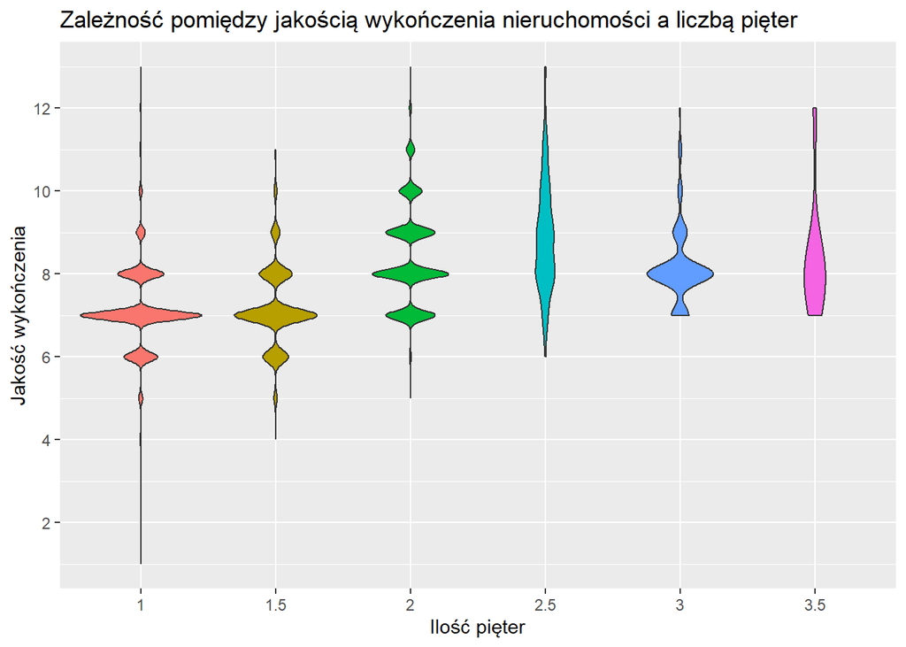

```r
df %>%
  select(grade, floors) %>%
  ggplot(aes(x = factor(floors), y = grade, fill = factor(floors))) + geom_violin() +
  scale_y_continuous(breaks = seq(0, max(df$grade), 2)) +
  labs(x = "Ilość pięter", y = "Jakość wykończenia", title = "Zależność pomiędzy jakością wykończenia nieruchomości a liczbą pięter") +
  theme(legend.position = "none")
```

**Komentarz: Zauważalny wzrost jakości wraz z większą ilością pięter**

## Zadanie 4

Jaka jest zależność między powierzchnią mieszkalną nieruchomości a powierzchnią gruntu w podziale na liczbę sypialni?

[figure not shown]

```r
df %>%
  mutate(size = case_when(
    bedrooms <= 0 ~ "0 sypialni",
    bedrooms <= 2 ~ "1-2 sypialnie",
    bedrooms <= 4 ~ "3-4 sypialnie",
    bedrooms > 4  ~ "4 i więcej sypialnie"
  )) %>%
  select(sqft_living, sqft_lot, size) %>%
  ggplot(aes(x = sqft_lot, y = sqft_living, color = factor(size))) +
  geom_point( alpha = 0.2) +
  geom_hline(yintercept = 2500, alpha = 0.5, linetype = "dashed") +
  scale_x_log10(labels = function(x) format(x, scientific = FALSE)) +
  facet_wrap(~ size, ncol = 2) +
  labs(x = "Powierzchnia mieszkalna (ft^2)", y = "Powierzchnia gruntu (ft^2)", title = "Zależność pomiędzy powierzchnią mieszkalną nieruchomości a powierzchnią gruntu", subtitle = "Z podziałem na liczbę sypialni") +
  theme(legend.position = "none")
```

**Komentarz: Wraz z ilością sypialni rośnie powierzchnia mieszkalna dla tej samej powierzchni gruntu**

## Zadanie 5

Rozważmy tylko nieruchomości, które miały remont. W której dekadzie było najwięcej przeprowadzonych remontów? Czy w poszczególnych dekadach jest porównywalny procent nieruchmości dla każdej wartości miary jakości i wykończenia nieruchomości?

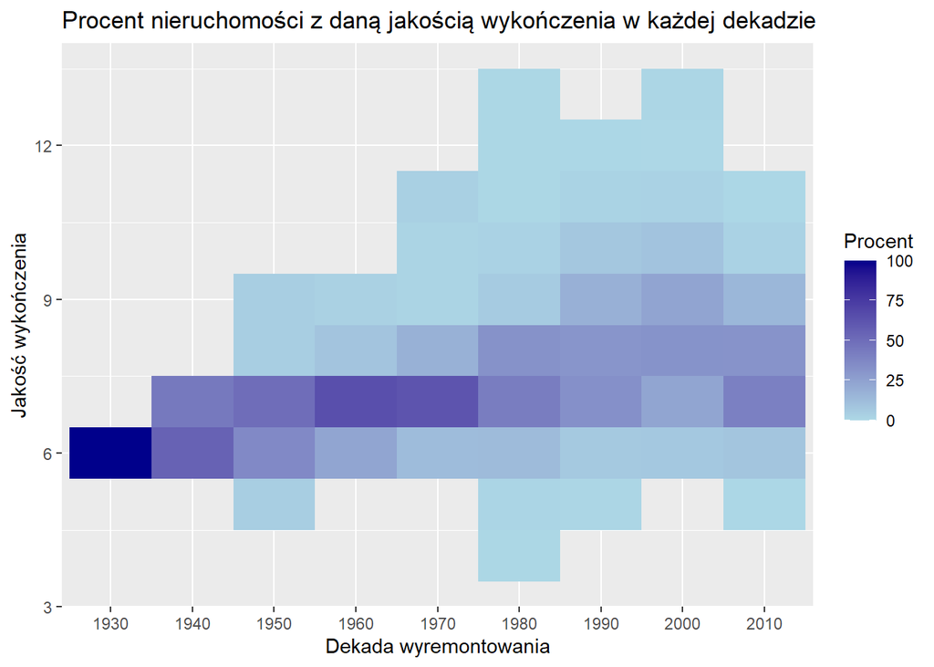

```r
dfr <- df %>%
  filter(yr_renovated > 0)
dfr %>%
  mutate(decade = paste0(substr(yr_renovated,1,3), "0")) %>%
  group_by(decade, grade) %>%
  summarise(count = n()) %>%
  ungroup() %>%
  group_by(decade) %>%
  mutate(percentage = (count / sum(count)) * 100) %>%
  ggplot(aes(x = decade, y = grade, fill = percentage)) + geom_tile() +
  scale_fill_gradient(low = "lightblue", high = "darkblue", limits = c(0,100)) +
  labs(x = "Dekada wyremontowania", y = "Jakość wykończenia", title = "Procent nieruchomości z daną jakością wykończenia w każdej dekadzie", fill = "Procent")
```

```r
dfr %>%
  mutate(decade = paste0(substr(yr_renovated,1,3), "0")) %>%
  group_by(decade) %>%
  summarise(count = n()) %>%
  arrange(-count) %>%
  top_n(1)
```

```
## # A tibble: 1 × 2
##   decade count
##   <chr>  <int>
## 1 2000     272
```

## Zadanie 6

Jak prezentuje się wartość minimalna, średnia i maksymalna ceny nieruchmości w podziele na rok budowy nieruchomości.

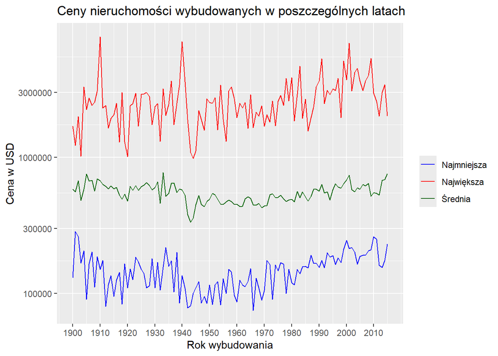

```r
df %>%
  group_by(yr_built) %>%
  summarise(min = min(price),
            mean = mean(price),
            max = max(price)) %>%
  ggplot(aes(x = yr_built)) +
           geom_line(aes(y = min, color = "Najmniejsza")) +
           geom_line(aes(y = mean, color = "Średnia")) +
           geom_line(aes(y = max, color = "Największa")) +
  scale_y_log10(labels = function(x) format(x, scientific = FALSE)) +
  scale_x_continuous(breaks=seq(min(df$yr_built), max(df$yr_built), 10)) +
  scale_color_manual(values = c("blue","red","darkgreen")) +
  labs(x = "Rok wybudowania", y = "Cena w USD", title = "Ceny nieruchomości wybudowanych w poszczególnych latach", color = "")
```